# R Notebook

## Setup

Setting up the current working directory and importing data from CSV, both train and test set Check the structure of data to see how many and what type of fields form the dataset

```r
setwd("C://Users//conne//Documents//Data Science//Profile//Git//R Projects//Housing Prediction")
getwd()
```

```
[1] "C:/Users/conne/Documents/Data Science/Profile/Git/R Projects/Housing Prediction"
```

```r
# read in OrderBreakdown.txt file into R as a data.frame named "data"
train <- read.table(file="train.csv", header=T, sep=",")
test <- read.table(file="test.csv", header=T, sep=",")
```

```r
#head(train,5)
#names(train)
str(train)
```

```
'data.frame':   1460 obs. of  82 variables:
 $ X            : int  1 2 3 4 5 6 7 8 9 10 ...
 $ Id           : int  1 2 3 4 5 6 7 8 9 10 ...
 $ MSSubClass   : int  60 20 60 70 60 50 20 60 50 190 ...
 $ MSZoning     : Factor w/ 5 levels "C (all)","FV",..: 4 4 4 4 4 4 4 4 5 4 ...
 $ LotFrontage  : int  65 80 68 60 84 85 75 NA 51 50 ...
 $ LotArea      : int  8450 9600 11250 9550 14260 14115 10084 10382 6120 7420 ...
 $ Street       : Factor w/ 2 levels "Grvl","Pave": 2 2 2 2 2 2 2 2 2 2 ...
 $ Alley        : Factor w/ 2 levels "Grvl","Pave": NA NA NA NA NA NA NA NA NA NA ...
 $ LotShape     : Factor w/ 4 levels "IR1","IR2","IR3",..: 4 4 1 1 1 1 4 1 4 4 ...
 $ LandContour  : Factor w/ 4 levels "Bnk","HLS","Low",..: 4 4 4 4 4 4 4 4 4 4 ...
 $ Utilities    : Factor w/ 2 levels "AllPub","NoSeWa": 1 1 1 1 1 1 1 1 1 1 ...
 $ LotConfig    : Factor w/ 5 levels "Corner","CulDSac",..: 5 3 5 1 3 5 5 1 5 1 ...
 $ LandSlope    : Factor w/ 3 levels "Gtl","Mod","Sev": 1 1 1 1 1 1 1 1 1 1 ...
 $ Neighborhood : Factor w/ 25 levels "Blmngtn","Blueste",..: 6 25 6 7 14 12 21 17 18 4 ...
```

[output cut: 68 more lines]

## Dividing the dataset into numeric and factor

```r
columnNames = names(train)
print(columnNames)
```

```
 [1] "X"             "Id"            "MSSubClass"    "MSZoning"      "LotFrontage"
 [6] "LotArea"       "Street"        "Alley"         "LotShape"      "LandContour"
[11] "Utilities"     "LotConfig"     "LandSlope"     "Neighborhood"  "Condition1"
[16] "Condition2"    "BldgType"      "HouseStyle"    "OverallQual"   "OverallCond"
[21] "YearBuilt"     "YearRemodAdd"  "RoofStyle"     "RoofMatl"      "Exterior1st"
[26] "Exterior2nd"   "MasVnrType"    "MasVnrArea"    "ExterQual"     "ExterCond"
[31] "Foundation"    "BsmtQual"      "BsmtCond"      "BsmtExposure"  "BsmtFinType1"
[36] "BsmtFinSF1"    "BsmtFinType2"  "BsmtFinSF2"    "BsmtUnfSF"     "TotalBsmtSF"
[41] "Heating"       "HeatingQC"     "CentralAir"    "Electrical"    "X1stFlrSF"
[46] "X2ndFlrSF"     "LowQualFinSF"  "GrLivArea"     "BsmtFullBath"  "BsmtHalfBath"
[51] "FullBath"      "HalfBath"      "BedroomAbvGr"  "KitchenAbvGr"  "KitchenQual"
[56] "TotRmsAbvGrd"  "Functional"    "Fireplaces"    "FireplaceQu"   "GarageType"
[61] "GarageYrBlt"   "GarageFinish"  "GarageCars"    "GarageArea"    "GarageQual"
[66] "GarageCond"    "PavedDrive"    "WoodDeckSF"    "OpenPorchSF"   "EnclosedPorch"
[71] "X3SsnPorch"    "ScreenPorch"   "PoolArea"      "PoolQC"        "Fence"
[76] "MiscFeature"   "MiscVal"       "MoSold"        "YrSold"        "SaleType"
[81] "SaleCondition" "SalePrice"
```

```r
#Initializing the separate dataframe to NULL so that in case of any error they don't keep previous records
trainNumeric = NULL
trainFactor = NULL
#Iterating over column names and putting it into appropriate basket
for (name in columnNames){
  print(is.null(trainFactor))
  if('factor' == toString(class(train[[name]]))){
    if(is.null(trainFactor)){
     trainFactor = train[name]
    }
    trainFactor[name] = train[[name]]
  } else{
    if(is.null(trainNumeric)){
     trainNumeric = train[name]
    }
    trainNumeric[name] = train[[name]]
  }
}
```

[output not shown]

[output cut: 67 more lines]

## The dependent variable needs to be added back to the factor dataframe. since that will be used in checking the correlation

Adding back the output varible so that each subdivision of dataset has Y using which correlation can be found

```r
trainFactor["SalePrice"] = train$SalePrice
```

## Removing two unused column from the dataset

X and Id are auto generated and is not required verifying the structure of numeric dataframe so as to see if our operation of dropping the variables was successfull

```r
trainNumeric$X = NULL
trainNumeric$Id = NULL
str(trainNumeric)
```

```
'data.frame':   1460 obs. of  37 variables:
 $ MSSubClass   : int  60 20 60 70 60 50 20 60 50 190 ...
 $ LotFrontage  : int  65 80 68 60 84 85 75 NA 51 50 ...
 $ LotArea      : int  8450 9600 11250 9550 14260 14115 10084 10382 6120 7420 ...
 $ OverallQual  : int  7 6 7 7 8 5 8 7 7 5 ...
 $ OverallCond  : int  5 8 5 5 5 5 5 6 5 6 ...
 $ YearBuilt    : int  2003 1976 2001 1915 2000 1993 2004 1973 1931 1939 ...
 $ YearRemodAdd : int  2003 1976 2002 1970 2000 1995 2005 1973 1950 1950 ...
 $ MasVnrArea   : int  196 0 162 0 350 0 186 240 0 0 ...
 $ BsmtFinSF1   : int  706 978 486 216 655 732 1369 859 0 851 ...
 $ BsmtFinSF2   : int  0 0 0 0 0 0 0 32 0 0 ...
 $ BsmtUnfSF    : int  150 284 434 540 490 64 317 216 952 140 ...
 $ TotalBsmtSF  : int  856 1262 920 756 1145 796 1686 1107 952 991 ...
 $ X1stFlrSF    : int  856 1262 920 961 1145 796 1694 1107 1022 1077 ...
 $ X2ndFlrSF    : int  854 0 866 756 1053 566 0 983 752 0 ...
```

[output cut: 23 more lines]

## Now comes the part where we will impute the dataframe for the missing values

There are two types of missing data:

[output not shown]

Assuming data is MCAR, too much missing data can be a problem too. Usually a safe maximum threshold is 5% of the total for large datasets. If missing data for a certain feature or sample is more than 5% then you probably should leave that feature or sample out. We therefore check for features (columns) and samples (rows) where more than 5% of the data is missing using a simple function https://datascienceplus.com/imputing-missing-data-with-r-mice-package/

The following fuction when used with apply gives the percentage of missing fields in each feature

```r
pMiss <- function(x){sum(is.na(x))/length(x)*100}
apply(trainNumeric,2,pMiss)
```

```
   MSSubClass   LotFrontage       LotArea   OverallQual   OverallCond     YearBuilt  YearRemodAdd
    0.0000000    17.7397260     0.0000000     0.0000000     0.0000000     0.0000000     0.0000000
   MasVnrArea    BsmtFinSF1    BsmtFinSF2     BsmtUnfSF   TotalBsmtSF     X1stFlrSF     X2ndFlrSF
    0.5479452     0.0000000     0.0000000     0.0000000     0.0000000     0.0000000     0.0000000
 LowQualFinSF     GrLivArea  BsmtFullBath  BsmtHalfBath      FullBath      HalfBath  BedroomAbvGr
    0.0000000     0.0000000     0.0000000     0.0000000     0.0000000     0.0000000     0.0000000
 KitchenAbvGr  TotRmsAbvGrd    Fireplaces   GarageYrBlt    GarageCars    GarageArea    WoodDeckSF
    0.0000000     0.0000000     0.0000000     5.5479452     0.0000000     0.0000000     0.0000000
  OpenPorchSF EnclosedPorch    X3SsnPorch   ScreenPorch      PoolArea       MiscVal        MoSold
    0.0000000     0.0000000     0.0000000     0.0000000     0.0000000     0.0000000     0.0000000
       YrSold     SalePrice
    0.0000000     0.0000000
```

```r
print('######')
```

```
[1] "######"
```

```r
apply(trainFactor,2,pMiss)
```

```
     MSZoning        Street         Alley      LotShape   LandContour     Utilities     LotConfig
   0.00000000    0.00000000   93.76712329    0.00000000    0.00000000    0.00000000    0.00000000
    LandSlope  Neighborhood    Condition1    Condition2      BldgType    HouseStyle     RoofStyle
   0.00000000    0.00000000    0.00000000    0.00000000    0.00000000    0.00000000    0.00000000
     RoofMatl   Exterior1st   Exterior2nd    MasVnrType     ExterQual     ExterCond    Foundation
   0.00000000    0.00000000    0.00000000    0.54794521    0.00000000    0.00000000    0.00000000
     BsmtQual      BsmtCond  BsmtExposure  BsmtFinType1  BsmtFinType2       Heating     HeatingQC
   2.53424658    2.53424658    2.60273973    2.53424658    2.60273973    0.00000000    0.00000000
   CentralAir    Electrical   KitchenQual    Functional   FireplaceQu    GarageType  GarageFinish
   0.00000000    0.06849315    0.00000000    0.00000000   47.26027397    5.54794521    5.54794521
   GarageQual    GarageCond    PavedDrive        PoolQC         Fence   MiscFeature      SaleType
   5.54794521    5.54794521    0.00000000   99.52054795   80.75342466   96.30136986    0.00000000
SaleCondition     SalePrice
   0.00000000    0.00000000
```

# We see here that some of the variables have a lot of NA values, and in those cases it would rather be better to drop them instead of of imputing them all.

We will drop features PoolQC, Fence , MiscFeature , FireplaceQu , Alley in trainFactor frame and in trainNumeric we will drop LotFrontage

```r
trainFactor$PoolQC = NULL
trainFactor$Fence = NULL
trainFactor$MiscFeature = NULL
trainFactor$FireplaceQu = NULL
trainFactor$Alley = NULL
trainNumeric$LotFrontage = NULL
```

# Checking the values again so as to see that we didn’t miss anything

All the values for missing data is less than or around 5%

```r
pMiss <- function(x){sum(is.na(x))/length(x)*100}
apply(trainNumeric,2,pMiss)
```

```
   MSSubClass       LotArea   OverallQual   OverallCond     YearBuilt  YearRemodAdd    MasVnrArea
    0.0000000     0.0000000     0.0000000     0.0000000     0.0000000     0.0000000     0.5479452
   BsmtFinSF1    BsmtFinSF2     BsmtUnfSF   TotalBsmtSF     X1stFlrSF     X2ndFlrSF  LowQualFinSF
    0.0000000     0.0000000     0.0000000     0.0000000     0.0000000     0.0000000     0.0000000
    GrLivArea  BsmtFullBath  BsmtHalfBath      FullBath      HalfBath  BedroomAbvGr  KitchenAbvGr
    0.0000000     0.0000000     0.0000000     0.0000000     0.0000000     0.0000000     0.0000000
 TotRmsAbvGrd    Fireplaces   GarageYrBlt    GarageCars    GarageArea    WoodDeckSF   OpenPorchSF
    0.0000000     0.0000000     5.5479452     0.0000000     0.0000000     0.0000000     0.0000000
EnclosedPorch    X3SsnPorch   ScreenPorch      PoolArea       MiscVal        MoSold        YrSold
    0.0000000     0.0000000     0.0000000     0.0000000     0.0000000     0.0000000     0.0000000
    SalePrice
    0.0000000
```

```r
print('######')
```

```
[1] "######"
```

```r
apply(trainFactor,2,pMiss)
```

```
     MSZoning        Street      LotShape   LandContour     Utilities     LotConfig     LandSlope
   0.00000000    0.00000000    0.00000000    0.00000000    0.00000000    0.00000000    0.00000000
 Neighborhood    Condition1    Condition2      BldgType    HouseStyle     RoofStyle      RoofMatl
   0.00000000    0.00000000    0.00000000    0.00000000    0.00000000    0.00000000    0.00000000
  Exterior1st   Exterior2nd    MasVnrType     ExterQual     ExterCond    Foundation      BsmtQual
   0.00000000    0.00000000    0.54794521    0.00000000    0.00000000    0.00000000    2.53424658
     BsmtCond  BsmtExposure  BsmtFinType1  BsmtFinType2       Heating     HeatingQC    CentralAir
   2.53424658    2.60273973    2.53424658    2.60273973    0.00000000    0.00000000    0.00000000
   Electrical   KitchenQual    Functional    GarageType  GarageFinish    GarageQual    GarageCond
   0.06849315    0.00000000    0.00000000    5.54794521    5.54794521    5.54794521    5.54794521
   PavedDrive      SaleType SaleCondition     SalePrice
   0.00000000    0.00000000    0.00000000    0.00000000
```

# The above analysis can be done with VIM as well , it also gives us a plot to show the distribution of the missing values

```
 Variables sorted by number of missings:
```

| Variable | Count |
| --- | --- |
| GarageYrBlt | 0.055479452 |
| MasVnrArea | 0.005479452 |
| MSSubClass | 0.000000000 |
| LotArea | 0.000000000 |
| OverallQual | 0.000000000 |
| OverallCond | 0.000000000 |
| YearBuilt | 0.000000000 |
| YearRemodAdd | 0.000000000 |
| BsmtFinSF1 | 0.000000000 |
| BsmtFinSF2 | 0.000000000 |

[output cut: 26 more lines]

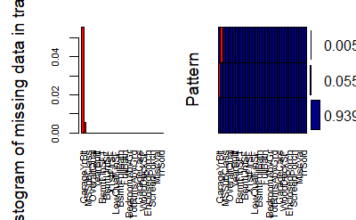

```r
library(VIM)
aggr_plot <- aggr(trainNumeric, col=c('navyblue','red'), numbers=TRUE, sortVars=TRUE, labels=names(trainNumeric), cex.axis=.7, gap=3, ylab=c("Histogram of missing data in trainNumeric","Pattern"))
```

```
not enough horizontal space to display frequencies
```

```
 Variables sorted by number of missings:
```

| Variable | Count |
| --- | --- |
| GarageType | 0.0554794521 |
| GarageFinish | 0.0554794521 |
| GarageQual | 0.0554794521 |
| GarageCond | 0.0554794521 |
| BsmtExposure | 0.0260273973 |
| BsmtFinType2 | 0.0260273973 |
| BsmtQual | 0.0253424658 |
| BsmtCond | 0.0253424658 |
| BsmtFinType1 | 0.0253424658 |
| MasVnrType | 0.0054794521 |

[output cut: 29 more lines]

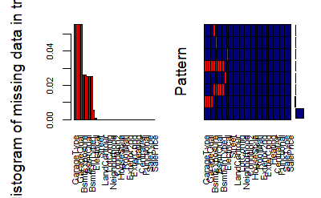

```r
aggr_plot <- aggr(trainFactor, col=c('navyblue','red'), numbers=TRUE, sortVars=TRUE, labels=names(trainFactor), cex.axis=.7, gap=3, ylab=c("Histogram of missing data in trainFactor","Pattern"))
```

# Now that we know what the missing values are, we will use mice package to impute the missing fields. for this pmm method which is predictive mean matching will be used, we will generate 5 imputed subsets

```r
require(mice)
imputer <- mice(trainNumeric,m=5,maxit=50,meth='pmm')
```

```
 * Please inspect the loggedEvents
```

```
Number of logged events: 1000
```

```r
summary(imputer)
```

```
Class: mids
Number of multiple imputations:  5
Imputation methods:
   MSSubClass       LotArea   OverallQual   OverallCond     YearBuilt  YearRemodAdd    MasVnrArea
           ""            ""            ""            ""            ""            ""         "pmm"
   BsmtFinSF1    BsmtFinSF2     BsmtUnfSF   TotalBsmtSF     X1stFlrSF     X2ndFlrSF  LowQualFinSF
           ""            ""            ""            ""            ""            ""            ""
    GrLivArea  BsmtFullBath  BsmtHalfBath      FullBath      HalfBath  BedroomAbvGr  KitchenAbvGr
           ""            ""            ""            ""            ""            ""            ""
 TotRmsAbvGrd    Fireplaces   GarageYrBlt    GarageCars    GarageArea    WoodDeckSF   OpenPorchSF
           ""            ""         "pmm"            ""            ""            ""            ""
EnclosedPorch    X3SsnPorch   ScreenPorch      PoolArea       MiscVal        MoSold        YrSold
           ""            ""            ""            ""            ""            ""            ""
    SalePrice
           ""
PredictorMatrix:
             MSSubClass LotArea OverallQual OverallCond YearBuilt YearRemodAdd MasVnrArea
MSSubClass            0       1           1           1         1            1          1
LotArea               1       0           1           1         1            1          1
OverallQual           1       1           0           1         1            1          1
OverallCond           1       1           1           0         1            1          1
YearBuilt             1       1           1           1         0            1          1
YearRemodAdd          1       1           1           1         1            0          1
             BsmtFinSF1 BsmtFinSF2 BsmtUnfSF TotalBsmtSF X1stFlrSF X2ndFlrSF LowQualFinSF
MSSubClass            1          1         1           1         1         1            1
LotArea               1          1         1           1         1         1            1
OverallQual           1          1         1           1         1         1            1
OverallCond           1          1         1           1         1         1            1
YearBuilt             1          1         1           1         1         1            1
YearRemodAdd          1          1         1           1         1         1            1
             GrLivArea BsmtFullBath BsmtHalfBath FullBath HalfBath BedroomAbvGr KitchenAbvGr
MSSubClass           1            1            1        1        1            1            1
LotArea              1            1            1        1        1            1            1
OverallQual          1            1            1        1        1            1            1
OverallCond          1            1            1        1        1            1            1
YearBuilt            1            1            1        1        1            1            1
YearRemodAdd         1            1            1        1        1            1            1
             TotRmsAbvGrd Fireplaces GarageYrBlt GarageCars GarageArea WoodDeckSF OpenPorchSF
MSSubClass              1          1           1          1          1          1           1
LotArea                 1          1           1          1          1          1           1
OverallQual             1          1           1          1          1          1           1
OverallCond             1          1           1          1          1          1           1
YearBuilt               1          1           1          1          1          1           1
YearRemodAdd            1          1           1          1          1          1           1
             EnclosedPorch X3SsnPorch ScreenPorch PoolArea MiscVal MoSold YrSold SalePrice
MSSubClass               1          1           1        1       1      1      1         1
LotArea                  1          1           1        1       1      1      1         1
OverallQual              1          1           1        1       1      1      1         1
OverallCond              1          1           1        1       1      1      1         1
YearBuilt                1          1           1        1       1      1      1         1
YearRemodAdd             1          1           1        1       1      1      1         1
Number of logged events:  1000
```

[output not shown]

```r
imputedtrainNumeric = complete(imputer, 1)
pMiss <- function(x){sum(is.na(x))/length(x)*100}
apply(imputedtrainNumeric,2,pMiss)
```

```
   MSSubClass       LotArea   OverallQual   OverallCond     YearBuilt  YearRemodAdd    MasVnrArea
            0             0             0             0             0             0             0
   BsmtFinSF1    BsmtFinSF2     BsmtUnfSF   TotalBsmtSF     X1stFlrSF     X2ndFlrSF  LowQualFinSF
            0             0             0             0             0             0             0
    GrLivArea  BsmtFullBath  BsmtHalfBath      FullBath      HalfBath  BedroomAbvGr  KitchenAbvGr
            0             0             0             0             0             0             0
 TotRmsAbvGrd    Fireplaces   GarageYrBlt    GarageCars    GarageArea    WoodDeckSF   OpenPorchSF
            0             0             0             0             0             0             0
EnclosedPorch    X3SsnPorch   ScreenPorch      PoolArea       MiscVal        MoSold        YrSold
            0             0             0             0             0             0             0
    SalePrice
            0
```

## Using polyreg to impute multi class categorical variable. we have reduced the number of iteration and number of multiple imputations to 2. since there are many features wuth missing data and having multiple iteration will render the results in slow manner

```r
require(mice)
imputerF <- mice(trainFactor,m=2,maxit=2,meth='polyreg')
```

```
Number of logged events: 44
```

```r
summary(imputerF)
```

```
Class: mids
Number of multiple imputations:  2
Imputation methods:
     MSZoning        Street      LotShape   LandContour     Utilities     LotConfig     LandSlope
           ""            ""            ""            ""            ""            ""            ""
 Neighborhood    Condition1    Condition2      BldgType    HouseStyle     RoofStyle      RoofMatl
           ""            ""            ""            ""            ""            ""            ""
  Exterior1st   Exterior2nd    MasVnrType     ExterQual     ExterCond    Foundation      BsmtQual
           ""            ""     "polyreg"            ""            ""            ""     "polyreg"
     BsmtCond  BsmtExposure  BsmtFinType1  BsmtFinType2       Heating     HeatingQC    CentralAir
    "polyreg"     "polyreg"     "polyreg"     "polyreg"            ""            ""            ""
   Electrical   KitchenQual    Functional    GarageType  GarageFinish    GarageQual    GarageCond
    "polyreg"            ""            ""     "polyreg"     "polyreg"     "polyreg"     "polyreg"
   PavedDrive      SaleType SaleCondition     SalePrice
           ""            ""            ""            ""
PredictorMatrix:
            MSZoning Street LotShape LandContour Utilities LotConfig LandSlope Neighborhood
MSZoning           0      1        1           1         1         1         1            1
Street             1      0        1           1         1         1         1            1
LotShape           1      1        0           1         1         1         1            1
LandContour        1      1        1           0         1         1         1            1
Utilities          1      1        1           1         0         1         1            1
LotConfig          1      1        1           1         1         0         1            1
            Condition1 Condition2 BldgType HouseStyle RoofStyle RoofMatl Exterior1st Exterior2nd
MSZoning             1          1        1          1         1        1           1           1
Street               1          1        1          1         1        1           1           1
LotShape             1          1        1          1         1        1           1           1
LandContour          1          1        1          1         1        1           1           1
Utilities            1          1        1          1         1        1           1           1
LotConfig            1          1        1          1         1        1           1           1
            MasVnrType ExterQual ExterCond Foundation BsmtQual BsmtCond BsmtExposure BsmtFinType1
MSZoning             1         1         1          1        1        1            1            1
Street               1         1         1          1        1        1            1            1
LotShape             1         1         1          1        1        1            1            1
LandContour          1         1         1          1        1        1            1            1
Utilities            1         1         1          1        1        1            1            1
LotConfig            1         1         1          1        1        1            1            1
            BsmtFinType2 Heating HeatingQC CentralAir Electrical KitchenQual Functional
MSZoning               1       1         1          1          1           1          1
Street                 1       1         1          1          1           1          1
LotShape               1       1         1          1          1           1          1
LandContour            1       1         1          1          1           1          1
Utilities              1       1         1          1          1           1          1
LotConfig              1       1         1          1          1           1          1
            GarageType GarageFinish GarageQual GarageCond PavedDrive SaleType SaleCondition
MSZoning             1            1          1          1          1        1             1
Street               1            1          1          1          1        1             1
LotShape             1            1          1          1          1        1             1
LandContour          1            1          1          1          1        1             1
Utilities            1            1          1          1          1        1             1
LotConfig            1            1          1          1          1        1             1
            SalePrice
MSZoning            1
Street              1
LotShape            1
LandContour         1
Utilities           1
LotConfig           1
Number of logged events:  44
```

|  | it | im | dep | meth | out |
| --- | --- | --- | --- | --- | --- |
| 1 | 1 | 1 | MasVnrType | polyreg | Exterior1stCBlock |
| 2 | 1 | 1 | BsmtQual | polyreg | Exterior1stAsphShn, Exterior1stCBlock, FoundationSlab, HeatingGasA, HeatingWall |
| 3 | 1 | 1 | BsmtCond | polyreg | Exterior1stAsphShn, Exterior1stCBlock, FoundationSlab, HeatingGasW, HeatingWall |
| 4 | 1 | 1 | BsmtExposure | polyreg | Exterior1stAsphShn, Exterior2ndCBlock, FoundationSlab, HeatingGasW, HeatingWall |
| 5 | 1 | 1 | BsmtFinType1 | polyreg | Exterior1stAsphShn, Exterior2ndCBlock, FoundationSlab, HeatingGasA, HeatingWall |
| 6 | 1 | 1 | BsmtFinType2 | polyreg | Exterior1stAsphShn, Exterior2ndCBlock, FoundationSlab, HeatingGasW, HeatingWall |

```r
imputedtrainFactor = complete(imputerF, 1)
pMiss <- function(x){sum(is.na(x))/length(x)*100}
apply(imputedtrainFactor,2,pMiss)
```

```
     MSZoning        Street      LotShape   LandContour     Utilities     LotConfig     LandSlope
            0             0             0             0             0             0             0
 Neighborhood    Condition1    Condition2      BldgType    HouseStyle     RoofStyle      RoofMatl
            0             0             0             0             0             0             0
  Exterior1st   Exterior2nd    MasVnrType     ExterQual     ExterCond    Foundation      BsmtQual
            0             0             0             0             0             0             0
     BsmtCond  BsmtExposure  BsmtFinType1  BsmtFinType2       Heating     HeatingQC    CentralAir
            0             0             0             0             0             0             0
   Electrical   KitchenQual    Functional    GarageType  GarageFinish    GarageQual    GarageCond
            0             0             0             0             0             0             0
   PavedDrive      SaleType SaleCondition     SalePrice
            0             0             0             0
```

# This method is to check if the total dimesion of the one hot encoded dataset doesn’t exceed the number of rows.

```r
totalDim=0
for (i in 1:length(names(trainFactor))){
  #print(length(levels(trainFactor[,i])))
  totalDim=totalDim+length(levels(trainFactor[,i]))
}
print(totalDim)
```

```
[1] 234
```

# One hot encinding using fastDummies is done to convert categorical variable into numeric

**Also Removing all the actual columns since they have now been converted to dummy variable

```r
dummyimputedtrainFactor <- fastDummies::dummy_cols(imputedtrainFactor, remove_first_dummy = TRUE)
#results <- fastDummies::dummy_cols(fastDummies_example, remove_first_dummy = TRUE)
print(paste('dimension of imputedtrainFactor = ' ,dim(imputedtrainFactor)))
```

```
[1] "dimension of imputedtrainFactor =  1460" "dimension of imputedtrainFactor =  39"
```

```r
print(paste('dimension of dummyimputedtrainFactor = ' ,dim(dummyimputedtrainFactor)))
```

```
[1] "dimension of dummyimputedtrainFactor =  1460" "dimension of dummyimputedtrainFactor =  235"
```

```r
for (name in names(imputedtrainFactor)){

  dummyimputedtrainFactor[name] = NULL
}
print(paste('dim of dummyimputedtrainFactor = ' ,dim(dummyimputedtrainFactor)))
```

```
[1] "dim of dummyimputedtrainFactor =  1460" "dim of dummyimputedtrainFactor =  196"
```

# Since the number of features after one hot encoding is 196. it will not be possible to visualize them together, for that reason let’s first filter out the features that are at least 0.5 in correlation value

```r
dummyimputedtrainFactor["SalePrice"] = train$SalePrice
highCorrVect = c()
correlationsFactor = cor(dummyimputedtrainFactor)
for (i in colnames(correlationsFactor)){
  for (j in colnames(correlationsFactor)){

      if ( abs(correlationsFactor[i,j]) > 0.5 & i != j ) {
       highCorrVect =  c(highCorrVect,cbind(i, "-" , j , ": " , correlationsFactor[i,j]))
        print(paste(i, "-" , j, ": ", correlationsFactor[i,j]))
      }

  }
}
```

```
[1] "MSZoning_RM - Neighborhood_OldTown :  0.56188074282636"
[1] "MSZoning_FV - Neighborhood_Somerst :  0.862807109977228"
[1] "Neighborhood_Somerst - MSZoning_FV :  0.862807109977228"
[1] "Neighborhood_OldTown - MSZoning_RM :  0.56188074282636"
[1] "Neighborhood_MeadowV - Exterior1st_CemntBd :  0.519798754904801"
[1] "Neighborhood_MeadowV - Exterior2nd_CmentBd :  0.524299794860035"
[1] "Neighborhood_NPkVill - Exterior2nd_Brk Cmn :  0.627945257087152"
[1] "Condition2_PosA - ExterCond_Ex :  0.576954417055882"
[1] "Condition2_RRAe - RoofStyle_Shed :  0.706864413816553"
[1] "RoofStyle_Flat - RoofMatl_Tar&Grv :  0.834913924147992"
[1] "RoofStyle_Shed - Condition2_RRAe :  0.706864413816553"
[1] "RoofMatl_Tar&Grv - RoofStyle_Flat :  0.834913924147992"
[1] "Exterior1st_MetalSd - Exterior2nd_MetalSd :  0.973065193762531"
[1] "Exterior1st_Wd Sdng - Exterior2nd_Wd Sdng :  0.859243932833037"
[1] "Exterior1st_HdBoard - Exterior2nd_HdBoard :  0.883271397030468"
```

[output cut: 57 more lines]

```r
i=0
j=0
print(paste(i,j))
```

```
[1] "0 0"
```

```r
highCorrVectNum = c()
correlationsNumeric = cor(imputedtrainNumeric)
for (i in colnames(correlationsNumeric)){
  for (j in colnames(correlationsNumeric)){

      if ( abs(correlationsNumeric[i,j]) > 0.5 & i != j ) {
       highCorrVectNum =  c(correlationsNumeric,cbind(i, "-" , j , ": " , correlationsNumeric[i,j]))
        print(paste(i, "-" , j, ": ", correlationsNumeric[i,j]))
      }

  }
}
```

```
[1] "OverallQual - YearBuilt :  0.572322768962362"
[1] "OverallQual - YearRemodAdd :  0.550683924194172"
[1] "OverallQual - TotalBsmtSF :  0.537808498612391"
[1] "OverallQual - GrLivArea :  0.593007430028651"
[1] "OverallQual - FullBath :  0.550599709368254"
[1] "OverallQual - GarageYrBlt :  0.560069322257168"
[1] "OverallQual - GarageCars :  0.600670716590715"
[1] "OverallQual - GarageArea :  0.562021756612608"
[1] "OverallQual - SalePrice :  0.790981600583805"
[1] "YearBuilt - OverallQual :  0.572322768962362"
[1] "YearBuilt - YearRemodAdd :  0.59285497634365"
[1] "YearBuilt - GarageYrBlt :  0.797226290843493"
[1] "YearBuilt - GarageCars :  0.537850091711105"
[1] "YearBuilt - SalePrice :  0.522897332879497"
[1] "YearRemodAdd - OverallQual :  0.550683924194172"
```

[output cut: 63 more lines]

```r
#install.packages('earth')
library(earth)
model <- earth(SalePrice ~ ., data=dummyimputedtrainFactor) # build model
ev <- evimp (model)
print(ev)
```

```
                     nsubsets   gcv    rss
ExterQual_TA               44 100.0  100.0
BsmtQual_Ex                43  75.0   75.7
Neighborhood_NoRidge       42  61.8   63.0
KitchenQual_Ex             41  56.7   58.1
BsmtExposure_Gd            39  47.9   49.7
Neighborhood_Crawfor       37  42.8   44.7
RoofMatl_WdShngl           32  35.4   37.4
Neighborhood_NridgHt       32  35.3   37.3
Neighborhood_StoneBr       32  35.3   37.3
BldgType_TwnhsE            32  35.3   37.3
BldgType_Twnhs             32  35.3   37.3
BsmtQual_TA                32  35.3   37.3
BsmtQual_Fa                32  35.3   37.3
CentralAir_N               32  35.3   37.3
HouseStyle_1Story          31  33.9   35.9
GarageType_Detchd          30  43.9>  45.4>
MasVnrType_None            30  32.1   34.1
Exterior1st_BrkFace        28  29.4   31.5
HouseStyle_SFoyer          27  28.1   30.2
KitchenQual_TA             26  26.7   28.9
RoofMatl_ClyTile           25  25.5   27.8
ExterQual_Ex               24  24.4   26.6
Neighborhood_Somerst       21  20.9   23.3
KitchenQual_Fa             20  21.3>  23.5>
BsmtFinType1_Unf           20  19.9   22.3
HouseStyle_SLvl            19  19.0   21.3
RoofStyle_Hip              18  17.9   20.3
ExterQual_Fa               16  31.1>  32.3>
LotConfig_CulDSac          16  16.0   18.4
Condition2_PosN            15  15.1   17.5
SaleType_New               15  15.1   17.5
Neighborhood_Edwards       14  22.2>  23.7>
Exterior1st_Plywood        13  13.3   15.7
Foundation_Slab            13  13.3   15.7
`MSZoning_C(all)`          12  12.5   14.8
Heating_GasW               11  11.5   13.9
Condition2_PosA            10  10.7   13.0
HouseStyle_2.5Fin           9   9.8   12.1
BsmtExposure_Av             6   7.6    9.5
MSZoning_RM                 5  21.0>  21.6>
GarageQual_Fa               5   6.8    8.6
BsmtExposure_Mn             4   5.9    7.6
GarageFinish_Fin            3   4.9    6.4
LotConfig_FR2               2   3.6    5.0
```

[figure not shown]

```r
plot(ev)
```

```r
#install.packages('earth')
library(earth)
modelN <- earth(SalePrice ~ ., data=imputedtrainNumeric) # build model
evN <- evimp (modelN)
print(evN)
```

```
             nsubsets   gcv    rss
OverallQual        16 100.0  100.0
GrLivArea          15  64.6   64.7
YearBuilt          14  45.2   45.4
BsmtFinSF1         13  35.2   35.6
X2ndFlrSF          12  31.3   31.7
OverallCond        10  25.0   25.4
LotArea             8  18.9   19.3
TotalBsmtSF         6  12.7   13.3
GarageCars          5  10.4   11.0
BedroomAbvGr        4   8.6    9.2
```

[figure not shown]

```r
plot(evN)
```

# Selected features that has correaltion of above 0.5 are

“SalePrice - OverallQual : 0.790981600583805” “SalePrice - YearBuilt : 0.522897332879497” “SalePrice - YearRemodAdd : 0.507100967111386” “SalePrice - TotalBsmtSF : 0.613580551559196” “SalePrice - X1stFlrSF : 0.605852184691915” “SalePrice - GrLivArea : 0.708624477612652” “SalePrice - FullBath : 0.560663762748446” “SalePrice - TotRmsAbvGrd : 0.533723155582028” “SalePrice - GarageYrBlt : 0.511868086625572” “SalePrice - GarageCars : 0.640409197258352” “SalePrice - GarageArea : 0.623431438918362” and “SalePrice - ExterQual_TA : -0.589043523409759” “SalePrice - BsmtQual_Ex : 0.553104847008939” “SalePrice - KitchenQual_TA : -0.519297853654885” “SalePrice - KitchenQual_Ex : 0.504093675905297”

using earth variable importance for numeric features BsmtFinSF1 , X2ndFlrSF, OverallCond, LotArea, BedroomAbvGr and for factors ExterQual_TA ,BsmtQual_Ex,Neighborhood_NoRidge,KitchenQual_Ex ,BsmtExposure_Gd,Neighborhood_Crawfor

This features will be incorporated in final model

```r
modeldata = imputedtrainNumeric[,c('OverallQual','YearBuilt','YearRemodAdd','TotalBsmtSF','X1stFlrSF','GrLivArea','FullBath','TotRmsAbvGrd','GarageYrBlt','GarageCars','GarageArea','BsmtFinSF1' , 'X2ndFlrSF', 'OverallCond', 'LotArea', 'BedroomAbvGr','SalePrice')]
modeldata = cbind(modeldata,dummyimputedtrainFactor[,c('ExterQual_TA','BsmtQual_Ex','KitchenQual_TA','KitchenQual_Ex', 'Neighborhood_NoRidge' , 'BsmtExposure_Gd', 'Neighborhood_Crawfor')])
```

# Splitting the data into train set and validation set

```r
trainSet <- sample(nrow(modeldata), 0.8*nrow(modeldata), replace = FALSE)
TrainingSet <- modeldata[trainSet,]
ValidationSet <- modeldata[-trainSet,]
summary(TrainingSet)
```

```
  OverallQual       YearBuilt     YearRemodAdd   TotalBsmtSF       X1stFlrSF        GrLivArea
 Min.   : 1.000   Min.   :1872   Min.   :1950   Min.   :   0.0   Min.   : 334.0   Min.   : 334
 1st Qu.: 5.000   1st Qu.:1954   1st Qu.:1967   1st Qu.: 797.5   1st Qu.: 875.8   1st Qu.:1131
 Median : 6.000   Median :1972   Median :1994   Median : 990.0   Median :1079.5   Median :1462
 Mean   : 6.087   Mean   :1971   Mean   :1985   Mean   :1054.1   Mean   :1159.1   Mean   :1509
 3rd Qu.: 7.000   3rd Qu.:2000   3rd Qu.:2004   3rd Qu.:1299.2   3rd Qu.:1411.2   3rd Qu.:1768
 Max.   :10.000   Max.   :2009   Max.   :2010   Max.   :6110.0   Max.   :4692.0   Max.   :5642
    FullBath     TotRmsAbvGrd     GarageYrBlt     GarageCars      GarageArea       BsmtFinSF1
 Min.   :0.00   Min.   : 2.000   Min.   :1900   Min.   :0.000   Min.   :   0.0   Min.   :   0.0
 1st Qu.:1.00   1st Qu.: 5.000   1st Qu.:1959   1st Qu.:1.000   1st Qu.: 336.0   1st Qu.:   0.0
 Median :2.00   Median : 6.000   Median :1978   Median :2.000   Median : 478.5   Median : 390.0
 Mean   :1.56   Mean   : 6.494   Mean   :1976   Mean   :1.754   Mean   : 473.5   Mean   : 445.6
 3rd Qu.:2.00   3rd Qu.: 7.000   3rd Qu.:2001   3rd Qu.:2.000   3rd Qu.: 576.0   3rd Qu.: 706.0
 Max.   :3.00   Max.   :14.000   Max.   :2010   Max.   :4.000   Max.   :1418.0   Max.   :5644.0
   X2ndFlrSF       OverallCond       LotArea        BedroomAbvGr     SalePrice
 Min.   :   0.0   Min.   :2.000   Min.   :  1491   Min.   :0.000   Min.   : 35311
 1st Qu.:   0.0   1st Qu.:5.000   1st Qu.:  7639   1st Qu.:2.000   1st Qu.:129800
 Median :   0.0   Median :5.000   Median :  9484   Median :3.000   Median :163250
 Mean   : 343.2   Mean   :5.604   Mean   : 10695   Mean   :2.858   Mean   :180209
 3rd Qu.: 728.0   3rd Qu.:6.000   3rd Qu.: 11604   3rd Qu.:3.000   3rd Qu.:214000
 Max.   :1818.0   Max.   :9.000   Max.   :215245   Max.   :8.000   Max.   :625000
  ExterQual_TA     BsmtQual_Ex      KitchenQual_TA   KitchenQual_Ex    Neighborhood_NoRidge
 Min.   :0.0000   Min.   :0.00000   Min.   :0.0000   Min.   :0.00000   Min.   :0.00000
 1st Qu.:0.0000   1st Qu.:0.00000   1st Qu.:0.0000   1st Qu.:0.00000   1st Qu.:0.00000
 Median :1.0000   Median :0.00000   Median :1.0000   Median :0.00000   Median :0.00000
 Mean   :0.6233   Mean   :0.07705   Mean   :0.5068   Mean   :0.06678   Mean   :0.02568
 3rd Qu.:1.0000   3rd Qu.:0.00000   3rd Qu.:1.0000   3rd Qu.:0.00000   3rd Qu.:0.00000
 Max.   :1.0000   Max.   :1.00000   Max.   :1.0000   Max.   :1.00000   Max.   :1.00000
 BsmtExposure_Gd  Neighborhood_Crawfor
 Min.   :0.0000   Min.   :0.00000
 1st Qu.:0.0000   1st Qu.:0.00000
 Median :0.0000   Median :0.00000
 Mean   :0.0976   Mean   :0.03853
 3rd Qu.:0.0000   3rd Qu.:0.00000
 Max.   :1.0000   Max.   :1.00000
```

```r
summary(ValidationSet)
```

```
  OverallQual       YearBuilt     YearRemodAdd   TotalBsmtSF       X1stFlrSF        GrLivArea
 Min.   : 1.000   Min.   :1880   Min.   :1950   Min.   :   0.0   Min.   : 372.0   Min.   : 630
 1st Qu.: 5.000   1st Qu.:1953   1st Qu.:1967   1st Qu.: 783.8   1st Qu.: 906.2   1st Qu.:1128
 Median : 6.000   Median :1973   Median :1993   Median :1018.0   Median :1098.5   Median :1468
 Mean   : 6.147   Mean   :1972   Mean   :1984   Mean   :1070.8   Mean   :1176.7   Mean   :1541
 3rd Qu.: 7.000   3rd Qu.:2001   3rd Qu.:2004   3rd Qu.:1292.5   3rd Qu.:1339.8   3rd Qu.:1809
 Max.   :10.000   Max.   :2010   Max.   :2010   Max.   :3200.0   Max.   :3228.0   Max.   :4676
    FullBath      TotRmsAbvGrd     GarageYrBlt     GarageCars      GarageArea
 Min.   :0.000   Min.   : 3.000   Min.   :1906   Min.   :0.000   Min.   :   0.0
 1st Qu.:1.000   1st Qu.: 5.000   1st Qu.:1960   1st Qu.:1.000   1st Qu.: 325.8
 Median :2.000   Median : 6.000   Median :1978   Median :2.000   Median : 480.0
 Mean   :1.586   Mean   : 6.613   Mean   :1976   Mean   :1.818   Mean   : 470.7
 3rd Qu.:2.000   3rd Qu.: 7.250   3rd Qu.:2001   3rd Qu.:2.000   3rd Qu.: 575.2
 Max.   :3.000   Max.   :12.000   Max.   :2010   Max.   :3.000   Max.   :1025.0
   BsmtFinSF1       X2ndFlrSF       OverallCond       LotArea       BedroomAbvGr
 Min.   :   0.0   Min.   :   0.0   Min.   :1.000   Min.   : 1300   Min.   :0.000
 1st Qu.:   0.0   1st Qu.:   0.0   1st Qu.:5.000   1st Qu.: 7374   1st Qu.:2.000
 Median : 338.0   Median :   0.0   Median :5.000   Median : 9465   Median :3.000
 Mean   : 435.9   Mean   : 362.1   Mean   :5.459   Mean   : 9804   Mean   :2.901
 3rd Qu.: 746.0   3rd Qu.: 739.5   3rd Qu.:6.000   3rd Qu.:11508   3rd Qu.:3.000
 Max.   :2260.0   Max.   :2065.0   Max.   :9.000   Max.   :53504   Max.   :6.000
   SalePrice       ExterQual_TA     BsmtQual_Ex     KitchenQual_TA   KitchenQual_Ex
 Min.   : 34900   Min.   :0.0000   Min.   :0.0000   Min.   :0.0000   Min.   :0.00000
 1st Qu.:131475   1st Qu.:0.0000   1st Qu.:0.0000   1st Qu.:0.0000   1st Qu.:0.00000
 Median :162200   Median :1.0000   Median :0.0000   Median :0.0000   Median :0.00000
 Mean   :183771   Mean   :0.6096   Mean   :0.1062   Mean   :0.4897   Mean   :0.07534
 3rd Qu.:211000   3rd Qu.:1.0000   3rd Qu.:0.0000   3rd Qu.:1.0000   3rd Qu.:0.00000
 Max.   :755000   Max.   :1.0000   Max.   :1.0000   Max.   :1.0000   Max.   :1.00000
 Neighborhood_NoRidge BsmtExposure_Gd   Neighborhood_Crawfor
 Min.   :0.00000      Min.   :0.00000   Min.   :0.00000
 1st Qu.:0.00000      1st Qu.:0.00000   1st Qu.:0.00000
 Median :0.00000      Median :0.00000   Median :0.00000
 Mean   :0.03767      Mean   :0.08904   Mean   :0.02055
 3rd Qu.:0.00000      3rd Qu.:0.00000   3rd Qu.:0.00000
 Max.   :1.00000      Max.   :1.00000   Max.   :1.00000
```

```r
require(randomForest)
# Create a Random Forest model with default parameters
model1 <- randomForest(SalePrice ~ ., data = TrainingSet, ntree = 500, mtry = 10, importance = TRUE)
model1
```

```
Call:
 randomForest(formula = SalePrice ~ ., data = TrainingSet, ntree = 500,      mtry = 10, importance = TRUE)
               Type of random forest: regression
                     Number of trees: 500
No. of variables tried at each split: 10

          Mean of squared residuals: 720735711
                    % Var explained: 87.58
```

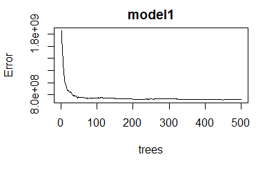

```r
plot(model1)
```

```r
which.min(model2$mse)
```

[output not shown]

[output not shown]

```r
pred_randomForest <- predict(model1, ValidationSet)
head(pred_randomForest)
```

```
       5        8       15       19       20       22
290459.7 215926.8 150080.7 157774.1 141015.3 131096.8
```

```r
sqrt(model1$mse[which.min(model1$mse)])
```

```
[1] 26767.61
```

# https://uc-r.github.io/random_forests

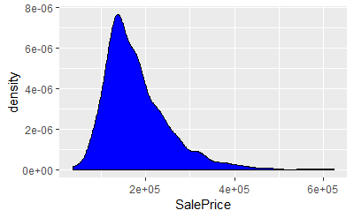

```r
require(ggplot2)
#plot( c(ValidationSet$SalePrice,pred_randomForest))
ggplot(data=TrainingSet) + geom_density(aes(x = SalePrice), fill="blue")
```

```r
require(Metrics)
rmsle(ValidationSet$SalePrice, pred_randomForest)
```

```
[1] 0.1627092
```